# OpenIntro Lab - Chapter 1

# OpenIntro Lab - Introduction to data

This notebook is the first chapter of my personal study book. The general aim is to learn how summarize and describe the raw information - the data. It is part of the first set of **OpenIntro** labs, that are part of the study of the book: **Introductory Statistics with Randomization and Simulation**. Lab avaliable from: [Introducton to Data](https://htmlpreview.github.io/?https://github.com/andrewpbray/oiLabs-base-R/blob/master/intro_to_data/intro_to_data.html)

We will use a data set collected by the **Centers for Disease Control and Prevention** (CDC), called **The Behavioral Risk Factor Surveillance System** (BRFSS). Avaliable from: [BRFSS](http://www.cdc.gov/brfss).

This R Notebooke is organized in the following way: there will always be a question about the dataset, followed by code chunks (R script) and its outputs. For some answers the output will be considered sufficient. For others a short answer will be written.

We will focus on a random sample of 20,000 people from the **BRFSS** survey conducted in 2000. While there are over 200 variables in this data set, we will work with a small subset.

### **Exercise 1**

How many cases are there in this data set? How many variables? For each variable, identify its data type (e.g. categorical, discrete).

```r
names(cdc)
```

```
[1] "genhlth"  "exerany"  "hlthplan" "smoke100" "height"   "weight"
[7] "wtdesire" "age"      "gender"
```

|  | genhlth | exerany | hlthplan | smoke100 | height | weight | wtdesire | age | gender |
| --- | --- | --- | --- | --- | --- | --- | --- | --- | --- |
| 1 | good | 0 | 1 | 0 | 70 | 175 | 175 | 77 | m |
| 2 | good | 0 | 1 | 1 | 64 | 125 | 115 | 33 | f |
| 3 | good | 1 | 1 | 1 | 60 | 105 | 105 | 49 | f |
| 4 | good | 1 | 1 | 0 | 66 | 132 | 124 | 42 | f |
| 5 | very good | 0 | 1 | 0 | 61 | 150 | 130 | 55 | f |
| 6 | very good | 1 | 1 | 0 | 64 | 114 | 114 | 55 | f |

|  | genhlth | exerany | hlthplan | smoke100 | height | weight | wtdesire | age | gender |
| --- | --- | --- | --- | --- | --- | --- | --- | --- | --- |
| 19995 | good | 0 | 1 | 1 | 69 | 224 | 224 | 73 | m |
| 19996 | good | 1 | 1 | 0 | 66 | 215 | 140 | 23 | f |
| 19997 | excellent | 0 | 1 | 0 | 73 | 200 | 185 | 35 | m |
| 19998 | poor | 0 | 1 | 0 | 65 | 216 | 150 | 57 | f |
| 19999 | good | 1 | 1 | 0 | 67 | 165 | 165 | 81 | f |
| 20000 | good | 1 | 1 | 1 | 69 | 170 | 165 | 83 | m |

```r
str(cdc)
```

```
'data.frame':   20000 obs. of  9 variables:
 $ genhlth : Factor w/ 5 levels "excellent","very good",..: 3 3 3 3 2 2 2 2 3 3 ...
 $ exerany : num  0 0 1 1 0 1 1 0 0 1 ...
 $ hlthplan: num  1 1 1 1 1 1 1 1 1 1 ...
 $ smoke100: num  0 1 1 0 0 0 0 0 1 0 ...
 $ height  : num  70 64 60 66 61 64 71 67 65 70 ...
 $ weight  : int  175 125 105 132 150 114 194 170 150 180 ...
 $ wtdesire: int  175 115 105 124 130 114 185 160 130 170 ...
 $ age     : int  77 33 49 42 55 55 31 45 27 44 ...
 $ gender  : Factor w/ 2 levels "m","f": 1 2 2 2 2 2 1 1 2 1 ...
```

**Answer**: There are 20000 cases and 9 variables in this dataset. We can see the types of each variable in the output above.

### **Exercise 2**

Create a numerical summary for `height` and `age`, and compute the interquartile range for each. Compute the relative frequency distribution for `gender` and `exerany`. How many males are in the sample? What proportion of the sample reports being in excellent health?

```r
summary(cdc$height)
```

```
   Min. 1st Qu.  Median    Mean 3rd Qu.    Max.
  48.00   64.00   67.00   67.18   70.00   93.00
```

```r
# interquartile range = 3rd Qu - 1st Qu
IQR_height <- 70-64
```

```r
IQR_height
```

```
[1] 6
```

```r
summary(cdc$age)
```

```
   Min. 1st Qu.  Median    Mean 3rd Qu.    Max.
  18.00   31.00   43.00   45.07   57.00   99.00
```

```r
# interquartile range = 3rd Qu - 1st Qu
IQR_age <- (57-31)
```

```r
IQR_age
```

```
[1] 26
```

```r
table(cdc$gender)
```

```
    m     f
 9569 10431
```

```r
table(cdc$gender)/20000
```

```
      m       f
0.47845 0.52155
```

```r
table(cdc$exerany)/20000
```

```
     0      1
0.2543 0.7457
```

**Answer**: There are 9569 males. The frequency distribution for `gender` and `exerany`, can be seen int the output above.

```r
summary(cdc$genhlth) / 20000
```

```
excellent very good      good      fair      poor
  0.23285   0.34860   0.28375   0.10095   0.03385
```

**Answer**: the proportion of the sample reports being in excellent health = 0.23285 or 23%.

### **Exercise 3**

What does the mosaic plot reveal about smoking habits and gender?

```r
gender_smoke <- table(cdc$gender,cdc$smoke100)
```

```r
gender_smoke
```

```
       0    1
  m 4547 5022
  f 6012 4419
```

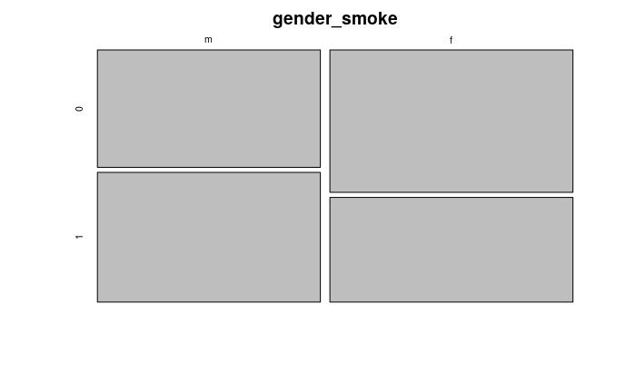

```r
mosaicplot(gender_smoke) #  column labels: 0 and 1. 1 indicates a respondent has smoked at least 100 cigarettes.
```

**Answer**: It seems that men smoke more often than women.